# Introduction to Single Cell Analysis

COVID-19 Edition

Dr. Elana Fertig, Spring 2020

### Week 2 Session 1

Step-by-step analysis: Gubin, Matthew M et al. “High-Dimensional Analysis Delineates Myeloid and Lymphoid Compartment Remodeling during Successful Immune-Checkpoint Cancer Therapy.” Cell 175.4 (2018): 1014-1030.e19.

### Loading Packages and Seurat Object

#### Load Packages

```r
library(GEOquery)
library(plyr)
library(Matrix)
library(Seurat)
library(ggplot2)
library(cowplot)
library(SAVER)
```

#### Load Seurat Object

```r
sobj<-readRDS(file="SingleCellCourseSeuratObject.rds")
```

### Visualizing Data

#### Detection of Variable Genes

```r
sobj <- FindVariableFeatures(object = sobj, mean.function = ExpMean, dispersion.function = LogVMR, nfeatures = 2000)
```

View output

```r
head(x = HVFInfo(object = sobj))
```

|  | mean | variance | variance.standardized |
| --- | --- | --- | --- |
| XKR4 | 0.0000000 | 0.0000000 | 0.0000000 |
| GM1992 | 0.0000000 | 0.0000000 | 0.0000000 |
| GM37381 | 0.0000000 | 0.0000000 | 0.0000000 |
| RP1 | 0.0000000 | 0.0000000 | 0.0000000 |
| RP1.1 | 0.0000000 | 0.0000000 | 0.0000000 |
| SOX17 | 0.0001412 | 0.0001412 | 0.9722442 |

Identify the 10 most highly variable genes

```r
top10 <- head(VariableFeatures(sobj), 10)
```

Plot variable features with and without labels

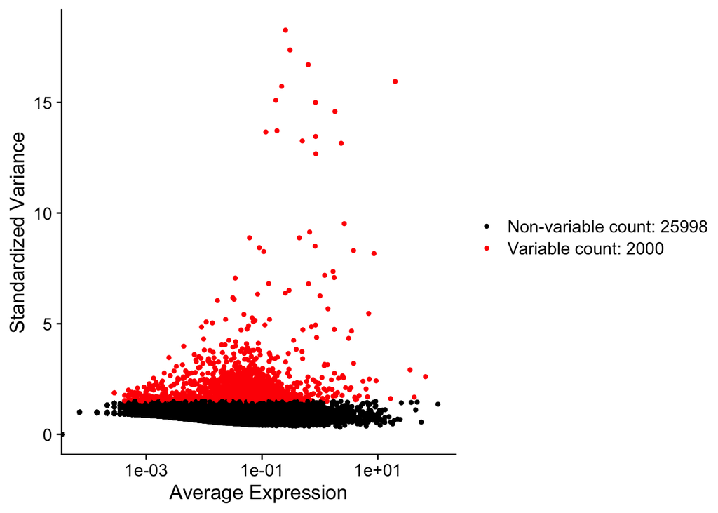

```r
plot1 <- VariableFeaturePlot(sobj)
plot2 <- LabelPoints(plot = plot1, points = top10, repel = TRUE)
plot1
```

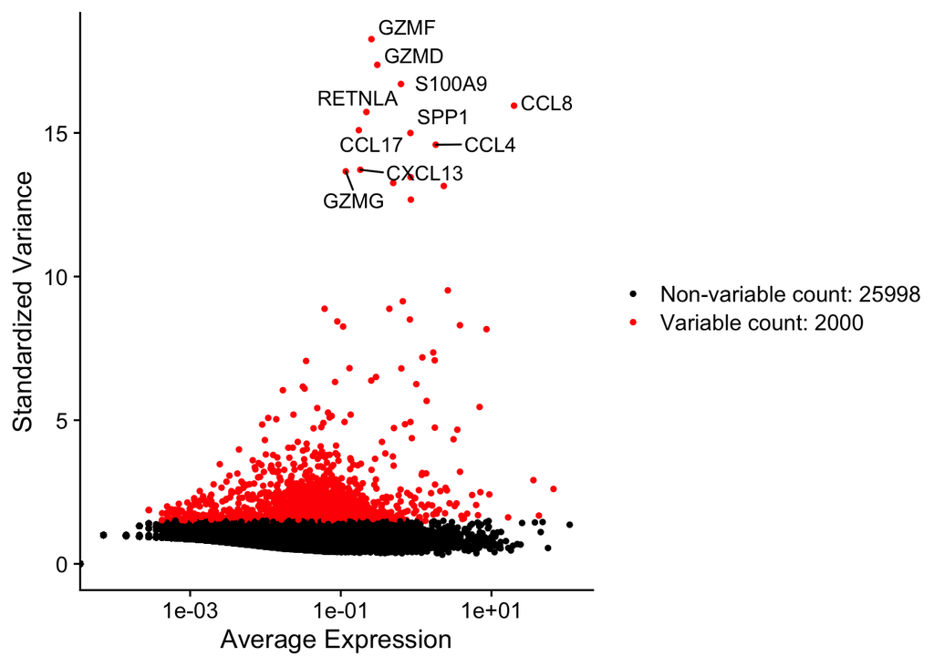

```r
plot2
```

Your single cell dataset likely contains ‘uninteresting’ sources of variation. This could include not only technical noise, but also batch effects, or even biological sources of variation (cell cycle stage). As suggested in Buettner et al, NBT, 2015, regressing these signals out of the analysis can improve downstream dimensionality reduction and clustering. To mitigate the effect of these signals, Seurat constructs linear models to predict gene expression based on user-defined variables. The scaled z-scored residuals of these models are stored in the scale.data slot, and are used for dimensionality reduction and clustering.

We can regress out cell-cell variation in gene expression driven by batch (if applicable), cell alignment rate (as provided by Drop-seq tools for Drop-seq data), the number of detected molecules, and mitochondrial gene expression. For cycling cells, we can also learn a ‘cell-cycle’ score (see example here) and regress this out as well. In this simple example here for post-mitotic blood cells, we regress on the number of detected molecules per cell as well as the percentage mitochondrial gene content.

Seurat v2.0 implements this regression as part of the data scaling process. Therefore, the RegressOut function has been deprecated, and replaced with the vars.to.regress argument in ScaleData.

```r
sobj <- ScaleData(object = sobj, vars.to.regress = c("nCounts_RNA", "percent.mito"))
```

#### Dimension Reduction

```r
sobj <- RunPCA(sobj, npcs = 100, ndims.print = 1:5, nfeatures.print = 5)
```

```
## PC_ 1
## Positive:  CTSS, FTL1, FTH1, LYZ2, CTSC
## Negative:  NKG7, MS4A4B, LTB, PTPRCAP, CD3D
## PC_ 2
## Positive:  X2810417H13RIK, STMN1, BIRC5, NUSAP1, HIST1H2AP
## Negative:  LTB, MS4A4B, NKG7, S100A9, CD7
## PC_ 3
## Positive:  MS4A7, C1QA, C1QC, SEPP1, C1QB
## Negative:  S100A9, S100A8, CXCL2, CCL3, CLEC4E
## PC_ 4
## Positive:  CCL8, PF4, MS4A7, C1QA, C1QB
## Negative:  SIGLECH, CD209D, COX6A2, LY6D, MZB1
## PC_ 5
## Positive:  CD3D, CD3G, CXCR6, TNFRSF4, CTLA4
## Negative:  NCR1, GZMA, CAR2, KLRA4, KLRA7
```

To overcome the extensive technical noise in any single gene for scRNA-seq data, Seurat clusters cells based on their PCA scores, with each PC essentially representing a ‘metagene’ that combines information across a correlated gene set. Determining how many PCs to include downstream is therefore an important step.

The JackStrawPlot visualizes the distribution of p-values for each PC.

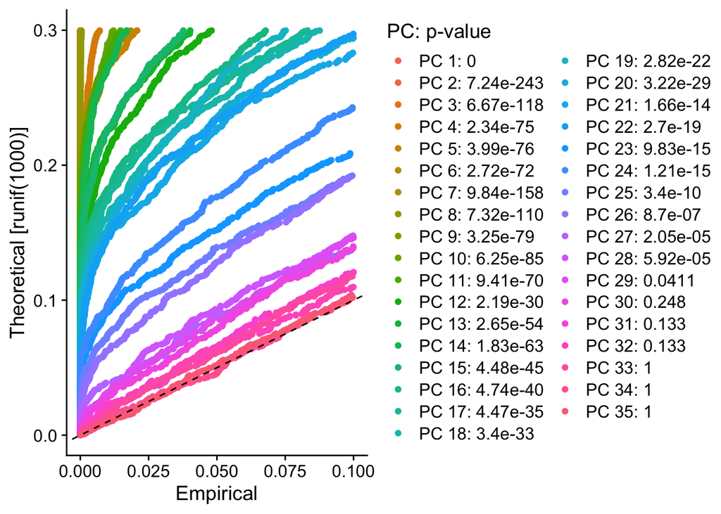

```r
sobj <- JackStraw(object = sobj, reduction = "pca", dims = 35, num.replicate = 100,  prop.freq = 0.1, verbose = FALSE)
sobj <- ScoreJackStraw(object = sobj, dims = 1:35, reduction = "pca")
JackStrawPlot(object = sobj, dims = 1:35, reduction = "pca")
```

A more ad hoc method for determining which PCs to use is to look at a plot of the standard deviations of the principle components and draw your cutoff where there is a clear elbow in the graph. This can be done with ElbowPlot. In this example, it looks like the elbow would fall around PC 25.

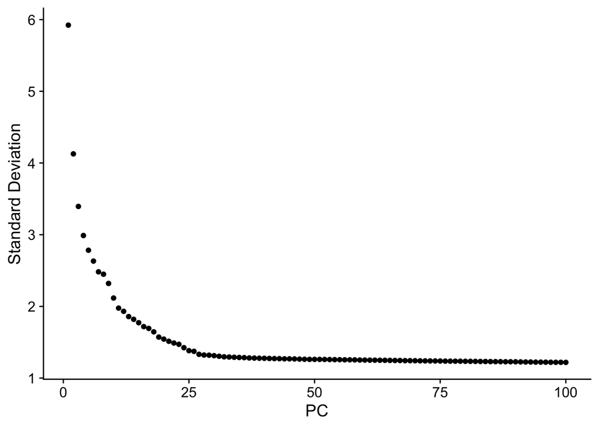

```r
ElbowPlot(sobj, ndims = 100)
```

#### Graph Based Clustering

```r
sobj <- FindNeighbors(sobj, reduction = "pca", dims = 1:25, nn.eps = 0.5)
sobj <- FindClusters(sobj, resolution = .34, n.start = 10)
```

```
## Modularity Optimizer version 1.3.0 by Ludo Waltman and Nees Jan van Eck
##
## Number of nodes: 14160
## Number of edges: 499424
##
## Running Louvain algorithm...
## Maximum modularity in 10 random starts: 0.8935
## Number of communities: 13
## Elapsed time: 1 seconds
```

```r
sobj <- RunUMAP(object = sobj, reduction = "pca", dims = 1:25,min.dist = 0.5, seed.use = 123)
```

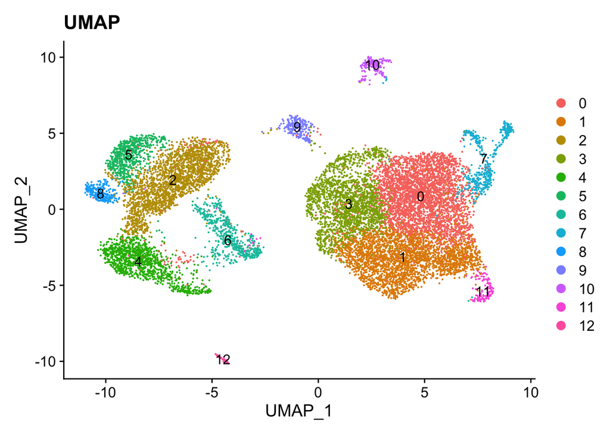

```r
p1 <- DimPlot(sobj, reduction = "umap", pt.size = 0.1,label=TRUE) + ggtitle(label = "UMAP")
p1
```

### Defining Clusters

#### Changing Number of Clusters

The number of clusters can be changed by specifying a resolution value in `FindClusters` For less clusters, reduce resolution value

```r
sobj_example <- FindNeighbors(sobj, reduction = "pca", dims = 1:25, nn.eps = 0.5)
sobj_example<- FindClusters(sobj_example, resolution = .2, n.start = 10)
```

```r
sobj_example<- RunUMAP(object = sobj_example, reduction="pca",dims = 1:25,min.dist = 0.5, seed.use = 1)
```

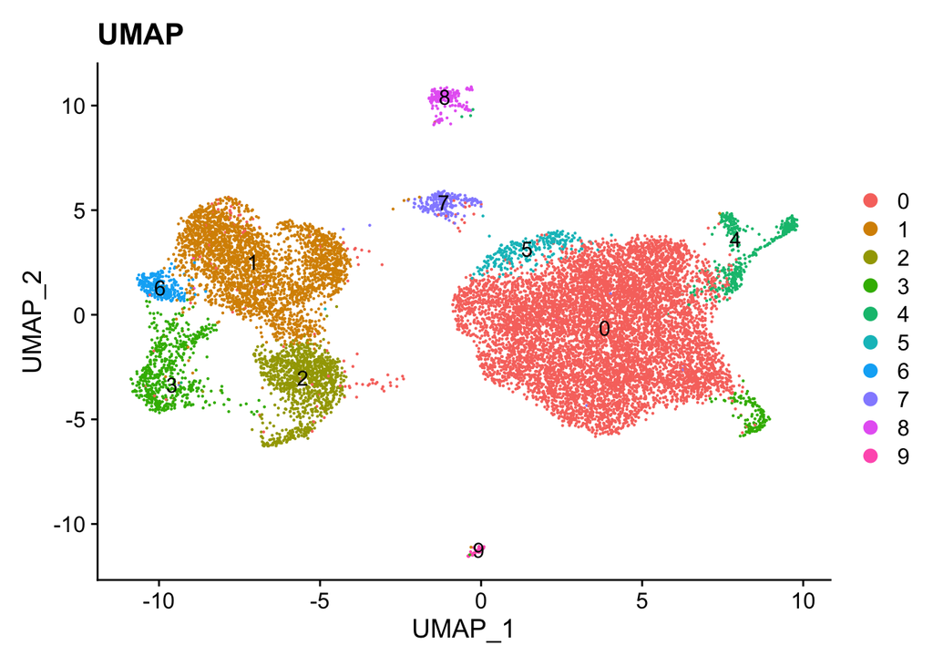

```r
p1 <- DimPlot(sobj_example, reduction = "umap", pt.size = 0.1,label=TRUE) + ggtitle(label = "UMAP")
p1
```

For more clusters, increase resolution value

```r
sobj_example <- FindNeighbors(sobj, reduction = "pca", dims = 1:25, nn.eps = 0.5)
sobj_example<- FindClusters(sobj_example, resolution = 3, n.start = 10)
```

```r
sobj_example <- RunUMAP(object = sobj_example, reduction = "pca", dims = 1:25,min.dist = 0.5, seed.use = 1)
```

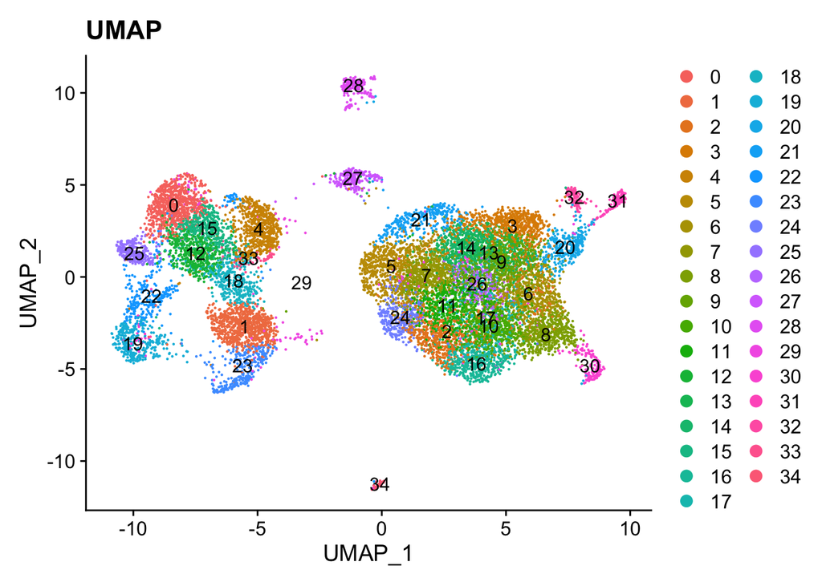

```r
p1 <- DimPlot(sobj_example, reduction = "umap", pt.size = 0.1,label=TRUE) + ggtitle(label = "UMAP")
p1
```

#### Visualize Treamtment Conditions

To visualize the treatment conditions side-by-side, we can use the split.by argument to show each condition colored by cluster.

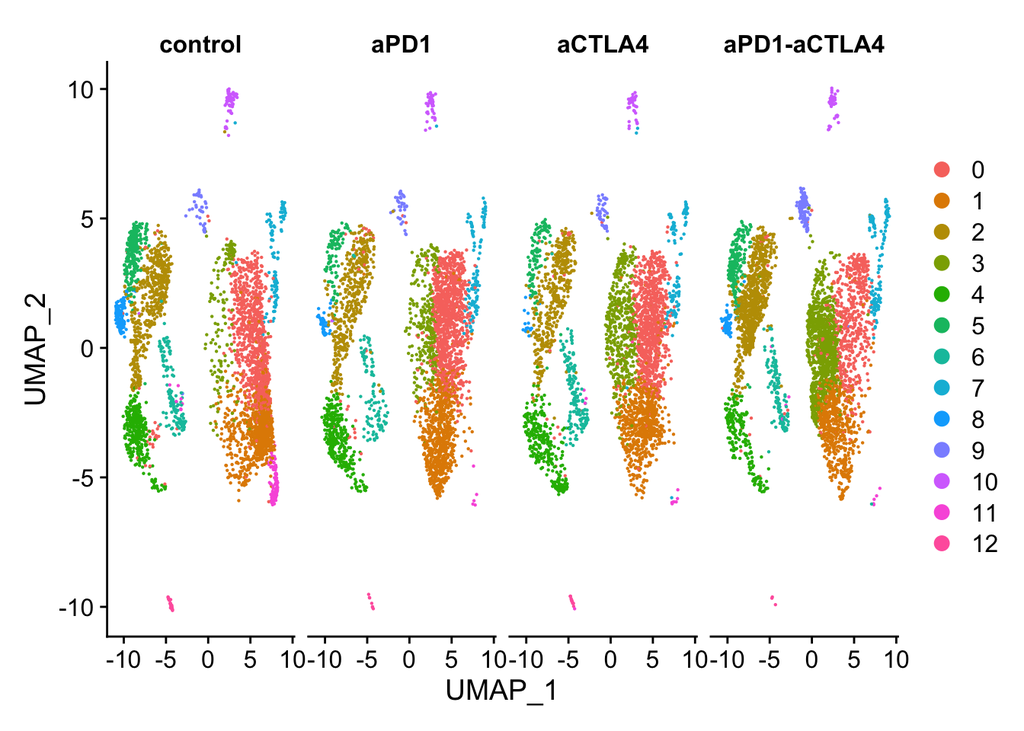

```r
DimPlot(sobj, reduction = "umap", split.by = "treatment")
```

#### Save Seurat Object

```r
saveRDS(sobj,file="SingleCellCourseSeuratObject_Wk2S1.rds")
```